# 图层(Layers)

2024-10-09

## 图层概述

ggplot2的图层结构鼓励我们以一种结构化的方式去设计和构造一张图.

在绘制一张图之前, 要考虑清楚加入这个图层有什么用. 一般来说, 一个图层有以下的三种用处:

- *展示数据(data layer)*. 我们可以直接观察图形中的模式发现数据中的模式, 比如总体结构, 局部结构, 异常值等. 在数据探索阶段, 这往往是唯一的一层
- *展示数据的统计结果(summary layer)*. 在我们对数据建模时, 往往需要对数据给出模型的预测. 显示数据有助于我们改进模型, 并可以帮助我们发现那些推理中会被遗漏的部分. 这一层通常在数据层之上.
- *添加其它元数据(metadata layer)*. 上下文, 注释, 引用(data about data). 元数据层帮助我们理解原始数据的含义, 有助于跨面板比较数据. 常见的元数据包括标签, 指示拐点, 异常值点等.

**举个例子**

地图是一种很常见的可视化图. - 用空间数据做背景图层 - 在缩放时会隐藏部分信息(元数据), 使得用户不会对数据的感知造成干扰 - 在导航时, 相当于使用了”模型”, 在背景图层上加入新的图

## geom–几何图形对象

```r
df <- data.frame(
  x = c(3, 1, 5),
  y = c(2, 4, 6),
  label = c("a","b","c")
)
p <- ggplot(df, aes(x, y, label = label)) +
  labs(x = NULL, y = NULL) + # Hide axis label
  theme(plot.title = element_text(size = 12)) # Shrink plot title
```

geom是ggplot2的基本构建块. 它本身以及它们之间的组合可以构造出很好用的几何图形. 它们基本都可以用`color`, `size`, `fill`来调节参数.

- `geom_area()`绘制的是线图到坐标轴围成的区域, 多组语句将时区域**堆叠**

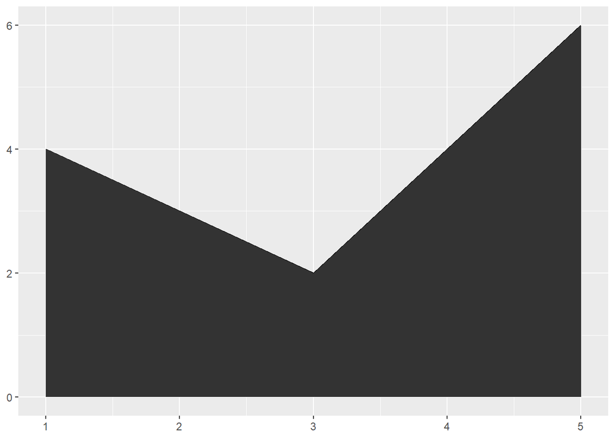

```r
p + geom_line() + geom_area()
```

- `geom_bar(stat = "identity")`绘制的是柱状图. 其中`stat = "identity"`因为默认会计算值, 从而报错.同一位置的多个条形图将堆叠在一起.

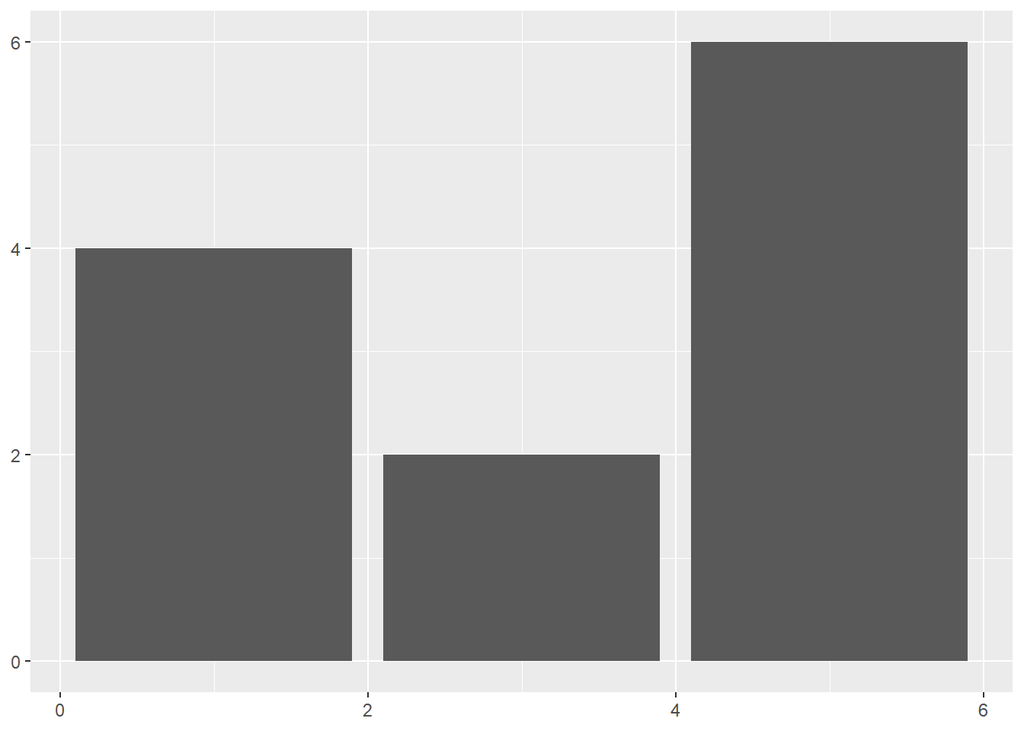

```r
p + geom_bar(stat = "identity")
```

- `geom_line()`绘制折线图. 后面会详细介绍`group`参数. `geom_line`的作用是将点从左到右连接起来; `geom_path`的作用是类似的, 但是它按照数据在dataframe中出现的顺序将点连接. 上面两个语句可以用参数`linetype`控制`solid, dashed, dotted`.

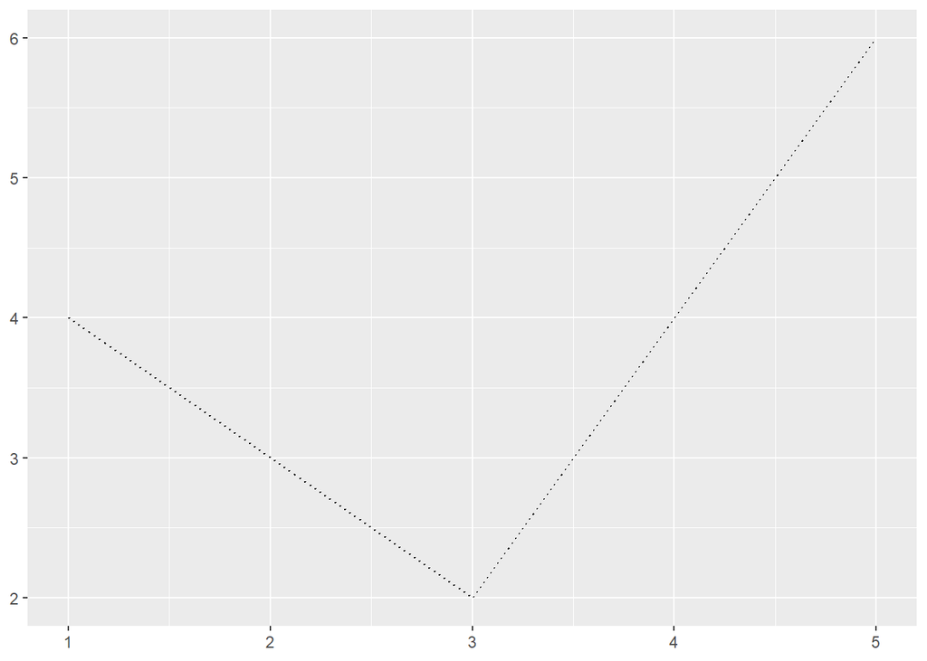

```r
p + geom_line(linetype = "dotted")
```

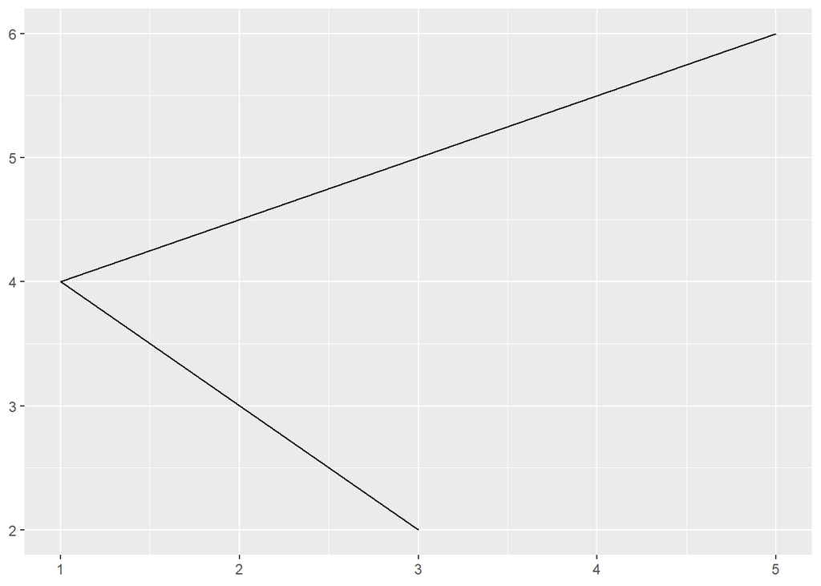

```r
p + geom_path(linetype = "solid")
```

- `geom_point()`绘制的是散点图. 一个重要的参数是`shape`.

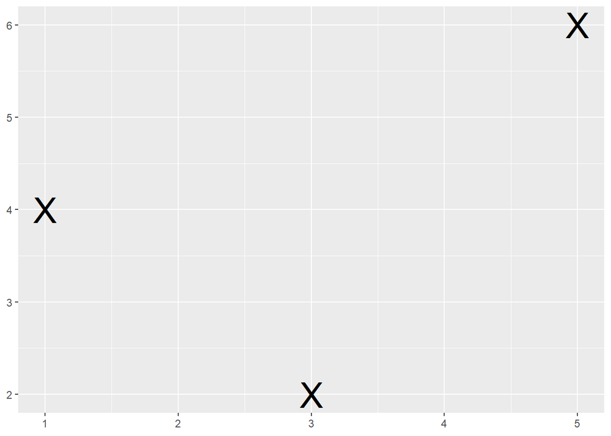

```r
p+geom_point(shape = "X", size = 10)
```

- `geom_polygon()`绘制的是多边形. 它绘制的是把`path`围起来的多边形. 在绘图之前往往需要将数据框的坐标和数据合并.

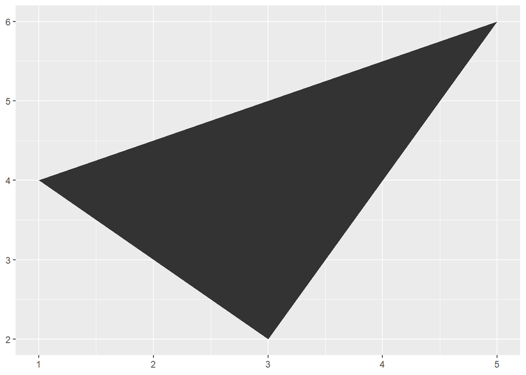

```r
p+geom_polygon()
```

- `geom_rect(), geom_tile(), geom_raster()`绘制矩形. 其中`geom_rect()`的参数是`xmin, ymin, xmax, ymax`用于控制矩形的四个点. `geom_tile()`用矩形的中心, 长, 宽作为参数`x,y,width,height`. `geom_raster()`是当`tile`的大小都相同时使用的.

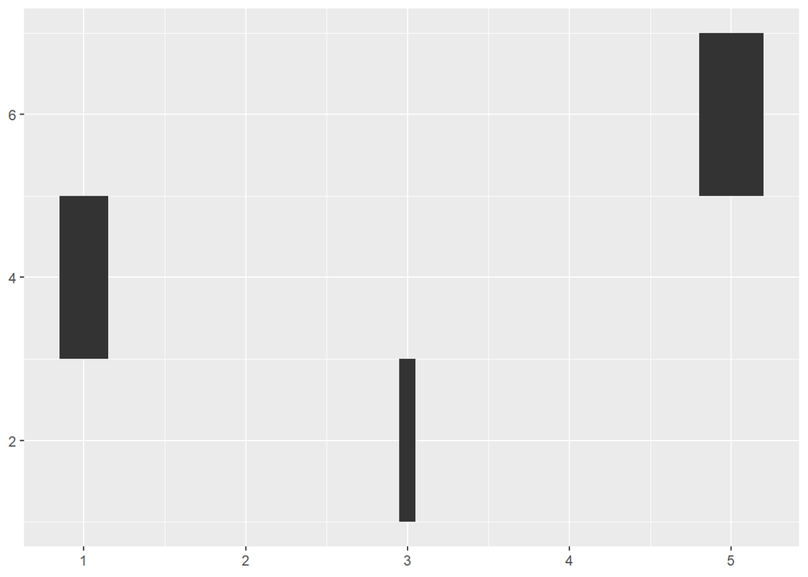

```r
p+geom_tile(width = c(0.1, 0.3, 0.4))
```